# Assignment 04: Earnings, Gender, and Unemployment by College Major

Author

Itzu Lin

Published

October 13, 2026

## Introduction

Choosing a college major is one of the most consequential decisions students make, and it connects to many higher-education and labor-market policy questions: how to advise students, how to think about student-loan repayment, and how to attract workers into fields such as teaching. This analysis uses data on recent college graduates (ages under 28) from the American Community Survey 2010–2012, compiled by FiveThirtyEight for the story [The Economic Guide To Picking A College Major](https://fivethirtyeight.com/features/the-economic-guide-to-picking-a-college-major/).

**Data source:** [`recent-grads.csv` on the FiveThirtyEight GitHub repository](https://github.com/fivethirtyeight/data/tree/master/college-majors). Each row is one college major (172 majors with complete data). The data is read directly from the web, so no data file is stored in this repository.

## Setup and Data

```r
library(tidyverse)
library(scales)

grads_url <- "https://raw.githubusercontent.com/fivethirtyeight/data/master/college-majors/recent-grads.csv"

stem_categories <- c("Engineering", "Computers & Mathematics",
                     "Biology & Life Science", "Physical Sciences")

grads <- read_csv(grads_url, show_col_types = FALSE) |>
  drop_na() |>  # removes the one major with missing values
  mutate(field_type = if_else(Major_category %in% stem_categories,
                              "STEM", "Non-STEM"))

source_note <- "Source: FiveThirtyEight, American Community Survey 2010-2012 (recent graduates under 28)"
```

## Visualization 1: Earnings and the Share of Women (Scatter Plot)

*How to read it: each point is one major. Further right means more women in the major; higher up means higher earnings. Bigger points are majors with more graduates.*

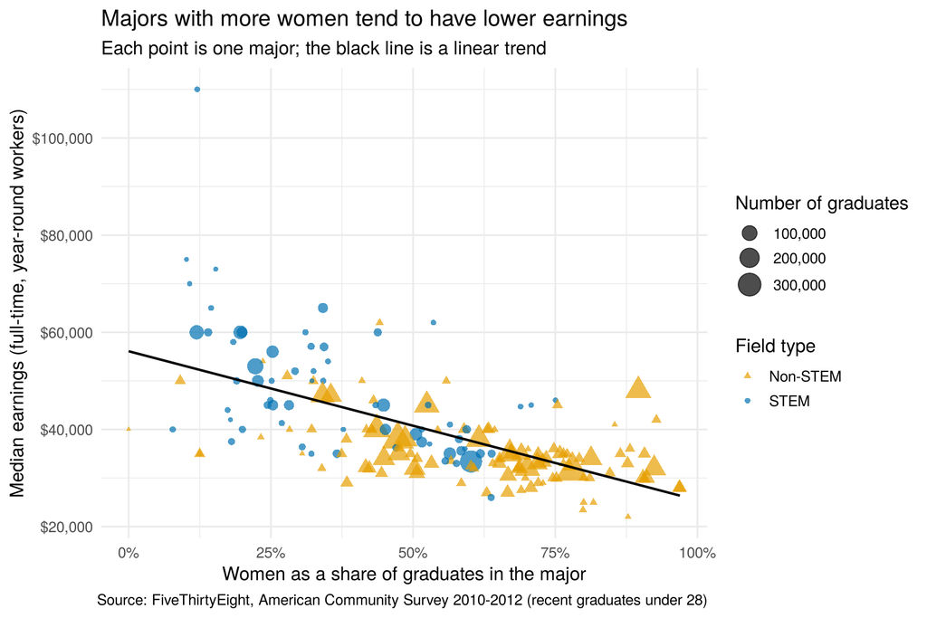

Figure 1

```r
ggplot(grads, aes(x = ShareWomen, y = Median)) +
  geom_point(aes(size = Total, color = field_type, shape = field_type),
             alpha = 0.7) +
  geom_smooth(method = "lm", se = FALSE, color = "black", linewidth = 0.8) +
  scale_x_continuous(labels = label_percent()) +
  scale_y_continuous(labels = label_dollar()) +
  scale_color_manual(values = c("STEM" = "#0072B2", "Non-STEM" = "#E69F00")) +
  scale_shape_manual(values = c("STEM" = 16, "Non-STEM" = 17)) +
  scale_size_continuous(labels = label_comma(), range = c(1, 8)) +
  labs(
    title = "Majors with more women tend to have lower earnings",
    subtitle = "Each point is one major; the black line is a linear trend",
    x = "Women as a share of graduates in the major",
    y = "Median earnings (full-time, year-round workers)",
    color = "Field type",
    shape = "Field type",
    size = "Number of graduates",
    caption = source_note
  ) +
  theme_minimal(base_size = 13)
```

Majors with a larger share of women tend to have lower median earnings: the trend line starts near $56,000 for a major with no women and falls by roughly $3,000 for every 10-percentage-point increase in the share of women (the correlation is -0.62). The STEM majors (blue) cluster toward the upper left, while most non-STEM majors (orange) sit toward the lower right. This is a pattern across majors, not evidence that women are paid less than men in the same job, because the data describe majors rather than individuals. For policy, it suggests that earnings differences across fields of study are closely tied to who enrolls in which fields, which matters for career advising and for the pay of female-dominated fields such as education and health.

## Visualization 2: Average Earnings by Major Category (Bar Chart)

*How to read it: each bar is a group of related majors, sorted from highest to lowest average earnings. The bar’s color shows how many of its graduates are women (darker = fewer women, lighter = more women).*

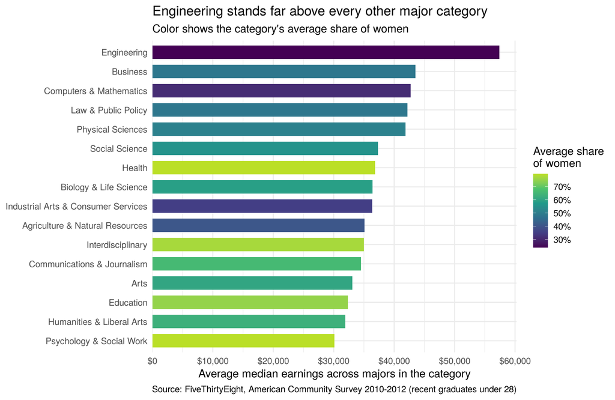

Figure 2

```r
category_summary <- grads |>
  group_by(Major_category) |>
  summarise(avg_median_earnings = mean(Median),
            avg_share_women = mean(ShareWomen),
            n_majors = n())

ggplot(category_summary,
       aes(x = reorder(Major_category, avg_median_earnings),
           y = avg_median_earnings,
           fill = avg_share_women)) +
  geom_col(width = 0.7) +
  coord_flip() +
  scale_y_continuous(labels = label_dollar(),
                     expand = expansion(mult = c(0, 0.05))) +
  scale_fill_viridis_c(labels = label_percent(), end = 0.9) +
  labs(
    title = "Engineering stands far above every other major category",
    subtitle = "Color shows the category's average share of women",
    x = NULL,
    y = "Average median earnings across majors in the category",
    fill = "Average share\nof women",
    caption = source_note
  ) +
  theme_minimal(base_size = 13)
```

Engineering majors have the highest average median earnings at about $57,400, well ahead of Business (about $43,500), while Psychology & Social Work (about $30,100) and Humanities & Liberal Arts (about $31,900) are at the bottom. The shading shows that the highest-paying category is only about 24% women, whereas Education (75% women) averages about $32,400 and Psychology & Social Work (79% women) is the lowest-paid category. Health, at about 80% women, lands in the middle at roughly $36,800. These gaps are relevant to debates about teacher pay and recruitment. Note that each category is a simple average across majors (not weighted by the number of graduates), and “Interdisciplinary” contains only one major.

## Visualization 3: Unemployment Rates Across Majors (Histogram)

*How to read it: the horizontal axis is the unemployment rate; the height of each bar is how many majors fall in that range. A tall bar means many majors have a similar unemployment rate.*

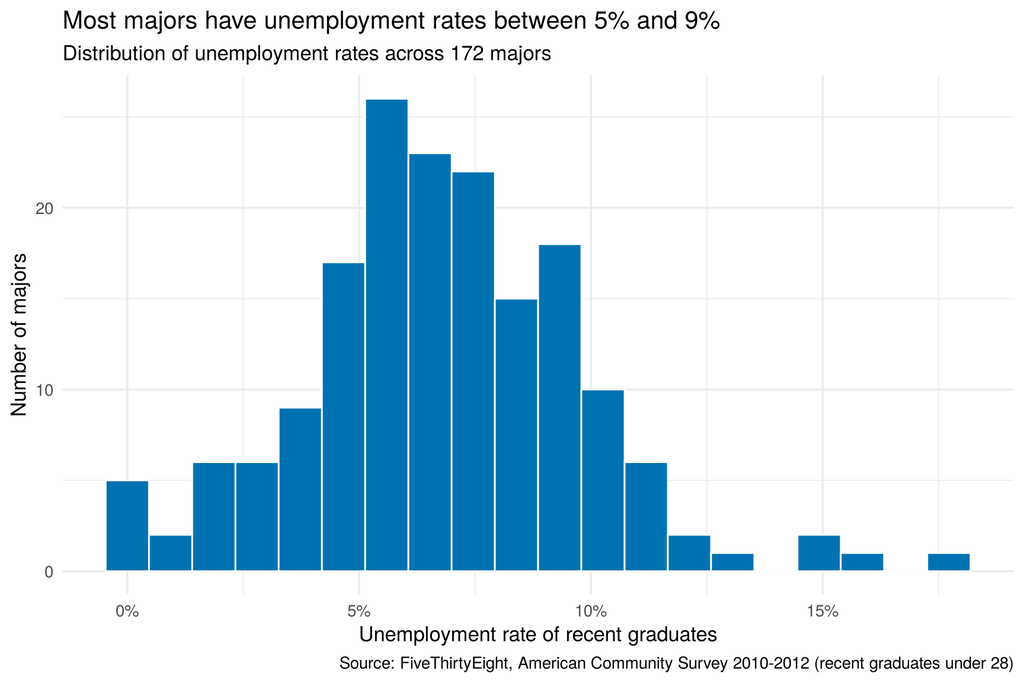

Figure 3

```r
ggplot(grads, aes(x = Unemployment_rate)) +
  geom_histogram(bins = 20, fill = "#0072B2", color = "white") +
  scale_x_continuous(labels = label_percent()) +
  labs(
    title = "Most majors have unemployment rates between 5% and 9%",
    subtitle = "Distribution of unemployment rates across 172 majors",
    x = "Unemployment rate of recent graduates",
    y = "Number of majors",
    caption = source_note
  ) +
  theme_minimal(base_size = 13)
```

Half of all majors have unemployment rates between about 5.0% and 8.7%, and the typical (median) major sits at about 6.8%. Only five majors have rates above 12%, and the highest, Nuclear Engineering at 17.7%, is based on just 17 survey respondents, so extreme values like this are noisy. These data cover 2010–2012, shortly after the Great Recession, so the rates reflect a weak labor market and would likely look different today. The policy takeaway is that even in high-earning fields unemployment can be substantial, so earnings alone do not capture the risks facing recent graduates.

## Visualization 4: STEM vs. Non-STEM Earnings (Boxplot)

*How to read it: the thick line inside each box is the middle (median) major, and the box covers the middle half of majors. Lines extend to typical high and low values, and dots are unusual majors.*

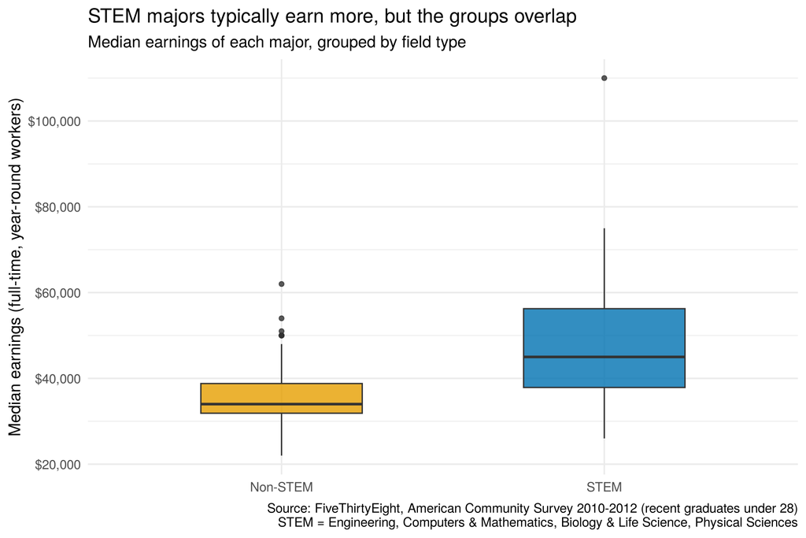

Figure 4

```r
ggplot(grads, aes(x = field_type, y = Median, fill = field_type)) +
  geom_boxplot(width = 0.5, alpha = 0.8, show.legend = FALSE) +
  scale_y_continuous(labels = label_dollar()) +
  scale_fill_manual(values = c("STEM" = "#0072B2", "Non-STEM" = "#E69F00")) +
  labs(
    title = "STEM majors typically earn more, but the groups overlap",
    subtitle = "Median earnings of each major, grouped by field type",
    x = NULL,
    y = "Median earnings (full-time, year-round workers)",
    caption = paste0(source_note,
                     "\nSTEM = Engineering, Computers & Mathematics, Biology & Life Science, Physical Sciences")
  ) +
  theme_minimal(base_size = 13)
```

The typical STEM major earns about $45,000 compared with about $34,000 for non-STEM majors, a gap of roughly $11,000. The spread is also much wider in STEM, from $26,000 (Zoology) up to $110,000 (Petroleum Engineering), so choosing a STEM field does not guarantee high pay. The groups overlap: 11 non-STEM majors, such as Actuarial Science ($62,000), earn more than the median STEM major. STEM majors also have slightly lower typical unemployment (about 6.1% versus 7.0%), which supports policies that expand access to STEM programs, though the definition of STEM used here is my own choice and a different definition (for example, including Health) could change the comparison.

## Conclusion

Taken together, the four graphs show that what a student studies is strongly related to both pay and labor-market risk. Earnings differ by tens of thousands of dollars across major categories (Visualizations 2 and 4), fields with more women tend to pay less (Visualization 1), and unemployment varies much less across majors than earnings do (Visualization 3). These are descriptive patterns from one time period and do not show that majors cause these outcomes, but they are relevant for policymakers thinking about student advising, loan repayment, and workforce pipelines into lower-paid but socially important fields such as education.

## Visualization Requirements Checklist

| Requirement Category | Specific Element / Code Used | Graph # (1, 2, 3, or 4) |
| --- | --- | --- |
| **Geom 1** | `geom_point()` | 1 |
| **Geom 2** | `geom_smooth()` | 1 |
| **Geom 3** | `geom_col()` | 2 |
| **Geom 4** | `geom_histogram()` | 3 |
| **Geom 5** | `geom_boxplot()` | 4 |
| **Aesthetic 1** *(inside `aes()`)* | `x` | 1, 2, 3, 4 |
| **Aesthetic 2** *(inside `aes()`)* | `y` | 1, 2, 4 |
| **Aesthetic 3** *(inside `aes()`)* | `size` | 1 |
| **Aesthetic 4** *(inside `aes()`)* | `color` | 1 |
| **Aesthetic 5** *(inside `aes()`)* | `shape` | 1 |
| **Aesthetic 6** *(inside `aes()`)* | `fill` | 2, 4 |
| **Non-Aesthetic 1** *(outside `aes()`)* | `alpha = 0.7` / `alpha = 0.8` | 1, 4 |
| **Non-Aesthetic 2** *(outside `aes()`)* | `method = "lm"` | 1 |
| **Non-Aesthetic 3** *(outside `aes()`)* | `se = FALSE` | 1 |
| **Non-Aesthetic 4** *(outside `aes()`)* | `linewidth = 0.8` | 1 |
| **Non-Aesthetic 5** *(outside `aes()`)* | `width = 0.7` / `width = 0.5` | 2, 4 |
| **Non-Aesthetic 6** *(outside `aes()`)* | `bins = 20` | 3 |
| **Custom Scale 1** | `scale_color_manual()` | 1 |
| **Custom Scale 2** | `scale_fill_viridis_c()` | 2 |